# Лабораторная работа №2

Установка и настройка инструментов для работы с Git

Липатников Андрей

1032253853@rudn.ru

Российский университет дружбы народов

2026-10-06

# Информация

## Докладчик

- Липатников Андрей
- Студент Российского университета дружбы народов им. П. Лумумбы
- 1032253853@rudn.ru

# Вводная часть

## Актуальность

- Системы контроля версий (VCS) — стандарт индустрии для совместной разработки.
- Git — децентрализованная VCS, требующая корректной настройки перед работой.
- Навыки установки и настройки Git обязательны для любого разработчика и исследователя.
- Цель презентации: показать процесс настройки рабочего окружения и подтвердить его работоспособность.

## Объект и предмет исследования

- **Объект**: инструменты работы с системами контроля версий (Git, gh, GPG).
- **Предмет**: процесс установки и настройки инструментов в ОС Fedora 41.
- **Конкретная задача**: создание рабочего пространства курса на основе шаблона и обеспечение верифицированных коммитов.

## Цели и задачи

- **Цель**: приобрести практические навыки установки и настройки инструментов для работы с Git.
- **Задачи**:
  1. Установить git и gh, выполнить базовую настройку.
  2. Создать SSH и GPG ключи, добавить их в GitHub.
  3. Настроить автоматическую подпись коммитов.
  4. Создать рабочее пространство курса и отправить изменения.

# Материалы и методы

## Используемое ПО и среда

- **ОС**: Fedora 41 (Sway) в VirtualBox.
- **Инструменты**:
  - `git` — система контроля версий.
  - `gh` — CLI-интерфейс GitHub.
  - `gpg` — создание и управление криптографическими ключами.
- **Терминал**: kitty, bash.

## Методика выполнения

- **Установка**: через пакетный менеджер `dnf`.
- **Настройка**: редактирование глобального конфига `~/.gitconfig`.
- **Генерация ключей**: `ssh-keygen` и `gpg --full-generate-key`.
- **Верификация**: проверка подписи коммитов через `git log --show-signature`.

# Результаты и демонстрация

## Установка и базовая настройка

- Установлены пакеты `git` и `gh`.
- Настроены глобальные параметры: имя, email, кодировка, ветка по умолчанию.

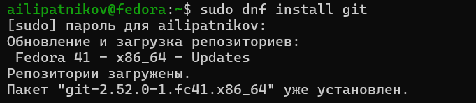

Установка git и базовая настройка

## Создание ключей

- **SSH-ключи**: RSA (4096 бит) и Ed25519 для аутентификации на GitHub.
- **GPG-ключ**: для подписи коммитов (обеспечение целостности и авторства).

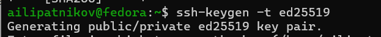

## Настройка подписи коммитов

- Экспорт публичного GPG-ключа и добавление его в настройки GitHub.
- Настройка git на использование ключа по умолчанию.
- Включение автоматической подписи всех коммитов.

```bash
git config --global user.signingkey 82B0275108BEA39D
git config --global commit.gpgsign true
```

## Создание рабочего пространства

- Использование `gh repo create` с шаблоном для создания структуры курса.
- Клонирование репозитория и инициализация рабочей директории.
- Выполнение `make prepare` для генерации структуры папок.

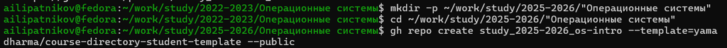

Создание репозитория и структуры

## Финальная проверка

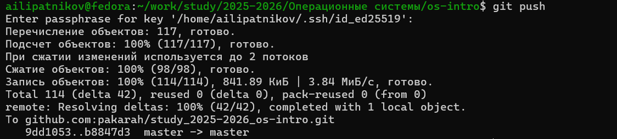

# Заключение

## Главный вывод

- Все задачи лабораторной работы выполнены.
- Рабочее окружение для работы с Git настроено и готово к использованию.
- Настроена верификация коммитов через GPG — это стандарт безопасности в современной разработке.
- Получены практические навыки, применимые в любых проектах.

## Вопросы?

- Готов ответить на вопросы по настройке Git, GPG-ключей и работе с шаблонами.
- Контакты: 1032253853@rudn.ru